# Building_Evaluating_LM_Model

Michael Longstreth

June 23, 2019

# 1 Objective

- Use the dataset healthcare data frame (see below) to fit
  - an OLSR linear (lm) model
  - a CART (rpart) model
  - a Bootstapped model
  - a Gradient Booting Machine (“GBM”) model
- to predict **costs**
- Explore the dataset as needed to guide your analysis
- Prepare your dataset (e.g., to avoid overfitting)
- Fit your models using lm and rpart
- Tune your models to optimize performance
- Show and *explain* your results, use plots where appropriate
- Evaluate model performance
- State your conclusions

```r
library(tidyverse)
healthcare <- read_csv('healthcare.csv')
```

# 2 Examine raw data from data set.

```r
head(healthcare, n = 5)
```

```
## # A tibble: 5 x 8
##   age_yrs gender body_mass no_children smoker region    prev_balance  costs
##     <dbl> <chr>      <dbl>       <dbl> <chr>  <chr>            <dbl>  <dbl>
## 1      18 female      42.2           0 yes    southeast      -17938. 38793.
## 2      43 female      30.7           2 no     northwest         195.  8311.
## 3      62 male        37.4           0 no     southwest       -4273. 12979.
## 4      49 female      23.2           2 no     northwest        1480. 10157.
## 5      46 male        40.4           2 no     northwest        -671.  8733.
```

```r
tail(healthcare, n = 5)
```

```
## # A tibble: 5 x 8
##   age_yrs gender body_mass no_children smoker region    prev_balance  costs
##     <dbl> <chr>      <dbl>       <dbl> <chr>  <chr>            <dbl>  <dbl>
## 1      42 male        35.8           2 no     southwest         875.  7160.
## 2      36 male        34.4           0 yes    southeast        5514. 37743.
## 3      28 male        38.1           0 no     southeast        -448.  2689.
## 4      36 female      19.9           0 no     northeast        1504.  5458.
## 5      37 male        37.1           1 yes    southeast       -6655. 39872.
```

```r
dim(healthcare)
```

```
## [1] 1338    8
```

```r
glimpse(healthcare)
```

```
## Observations: 1,338
## Variables: 8
## $ age_yrs      <dbl> 18, 43, 62, 49, 46, 63, 41, 55, 52, 25, 62, 48, 1...
## $ gender       <chr> "female", "female", "male", "female", "male", "ma...
## $ body_mass    <dbl> 42.240, 30.685, 37.400, 23.180, 40.375, 36.765, 3...
## $ no_children  <dbl> 0, 2, 0, 2, 2, 0, 3, 2, 0, 0, 0, 0, 1, 5, 2, 0, 1...
## $ smoker       <chr> "yes", "no", "no", "no", "no", "no", "no", "no", ...
## $ region       <chr> "southeast", "northwest", "southwest", "northwest...
## $ prev_balance <dbl> -17938.42104, 195.25679, -4272.92335, 1480.08209,...
## $ costs        <dbl> 38792.686, 8310.839, 12979.358, 10156.783, 8733.2...
```

# 3 Convert categorical variable to factors and add binomial varible of same in advance of analysis.

```r
library(purrr)
healthcare[,c(2,5,6)] <- map(healthcare[,c(2,5,6)], as.factor)
healthcare$smoker_num <- ifelse(healthcare$smoker == "yes", 1, 0)
healthcare$gender_num <- ifelse(healthcare$gender == "male", 1, 0)
```

# 4 View balance of categorical variables in dataset.

```r
library(gmodels)
CrossTable(healthcare$region)
```

```
##
##
##    Cell Contents
## |-------------------------|
## |                       N |
## |         N / Table Total |
## |-------------------------|
##
##
## Total Observations in Table:  1338
##
##
##           | northeast | northwest | southeast | southwest |
##           |-----------|-----------|-----------|-----------|
##           |       324 |       325 |       364 |       325 |
##           |     0.242 |     0.243 |     0.272 |     0.243 |
##           |-----------|-----------|-----------|-----------|
##
##
##
##
```

```r
CrossTable(healthcare$gender)
```

```
##
##
##    Cell Contents
## |-------------------------|
## |                       N |
## |         N / Table Total |
## |-------------------------|
##
##
## Total Observations in Table:  1338
##
##
##           |    female |      male |
##           |-----------|-----------|
##           |       662 |       676 |
##           |     0.495 |     0.505 |
##           |-----------|-----------|
##
##
##
##
```

```r
CrossTable(healthcare$smoker)
```

```
##
##
##    Cell Contents
## |-------------------------|
## |                       N |
## |         N / Table Total |
## |-------------------------|
##
##
## Total Observations in Table:  1338
##
##
##           |        no |       yes |
##           |-----------|-----------|
##           |      1064 |       274 |
##           |     0.795 |     0.205 |
##           |-----------|-----------|
##
##
##
##
```

# 5 Check for missing data; confirmed no data missing.

```r
sapply(healthcare, function(x) sum(is.na(x)))
```

```
##      age_yrs       gender    body_mass  no_children       smoker
##            0            0            0            0            0
##       region prev_balance        costs   smoker_num   gender_num
##            0            0            0            0            0
```

# 6 Do initial correlation check on variables, removing factors.

```r
healthcare_factors <- c(2, 5, 6)
cor(healthcare[,-healthcare_factors])
```

```
##                  age_yrs   body_mass no_children prev_balance      costs
## age_yrs       1.00000000 0.109271882  0.04246900   0.07003449 0.29900819
## body_mass     0.10927188 1.000000000  0.01275890   0.01443067 0.19834097
## no_children   0.04246900 0.012758901  1.00000000   0.01405894 0.06799823
## prev_balance  0.07003449 0.014430673  0.01405894   1.00000000 0.06350883
## costs         0.29900819 0.198340969  0.06799823   0.06350883 1.00000000
## smoker_num   -0.02501875 0.003750426  0.00767312   0.01206671 0.78725143
## gender_num   -0.02085587 0.046371151  0.01716298  -0.06836054 0.05729206
##                smoker_num  gender_num
## age_yrs      -0.025018752 -0.02085587
## body_mass     0.003750426  0.04637115
## no_children   0.007673120  0.01716298
## prev_balance  0.012066709 -0.06836054
## costs         0.787251430  0.05729206
## smoker_num    1.000000000  0.07618482
## gender_num    0.076184817  1.00000000
```

```r
summary(healthcare)
```

```
##     age_yrs         gender      body_mass      no_children    smoker
##  Min.   :18.00   female:662   Min.   :15.96   Min.   :0.000   no :1064
##  1st Qu.:27.00   male  :676   1st Qu.:26.30   1st Qu.:0.000   yes: 274
##  Median :39.00                Median :30.40   Median :1.000
##  Mean   :39.21                Mean   :30.66   Mean   :1.095
##  3rd Qu.:51.00                3rd Qu.:34.69   3rd Qu.:2.000
##  Max.   :64.00                Max.   :53.13   Max.   :5.000
##        region     prev_balance           costs         smoker_num
##  northeast:324   Min.   :-27607.54   Min.   : 1122   Min.   :0.0000
##  northwest:325   1st Qu.: -1340.00   1st Qu.: 4740   1st Qu.:0.0000
##  southeast:364   Median :   -13.35   Median : 9382   Median :0.0000
##  southwest:325   Mean   :   136.09   Mean   :13270   Mean   :0.2048
##                  3rd Qu.:  1427.87   3rd Qu.:16640   3rd Qu.:0.0000
##                  Max.   : 30313.76   Max.   :63770   Max.   :1.0000
##    gender_num
##  Min.   :0.0000
##  1st Qu.:0.0000
##  Median :1.0000
##  Mean   :0.5052
##  3rd Qu.:1.0000
##  Max.   :1.0000
```

# 7 Perform initial analysis of variables in dataset using ggplot2.

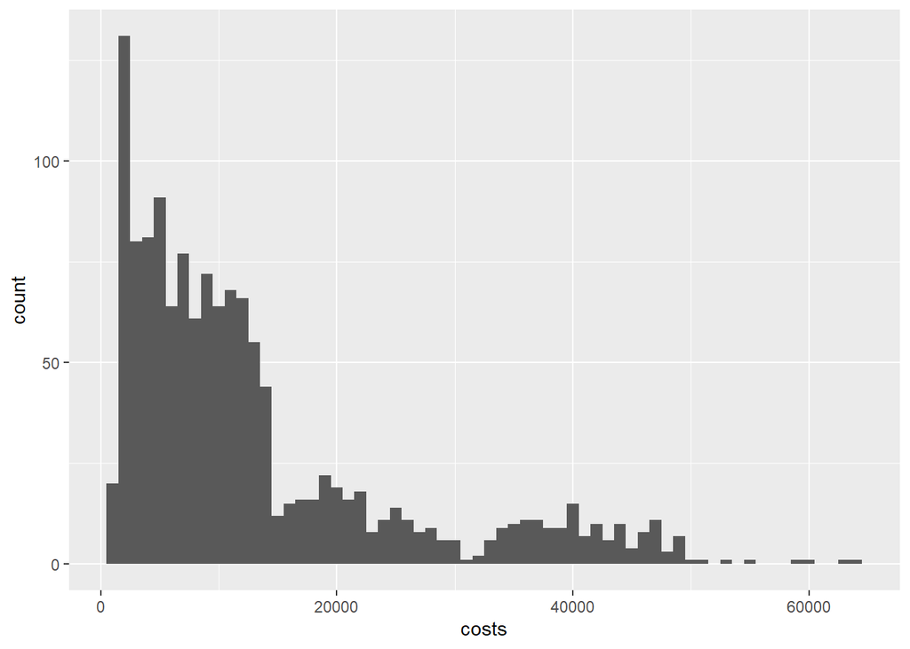

```r
library(ggplot2)
#Histogram of Cost
ggplot(healthcare, aes(x = costs)) +
  geom_histogram(binwidth = 1000)
```

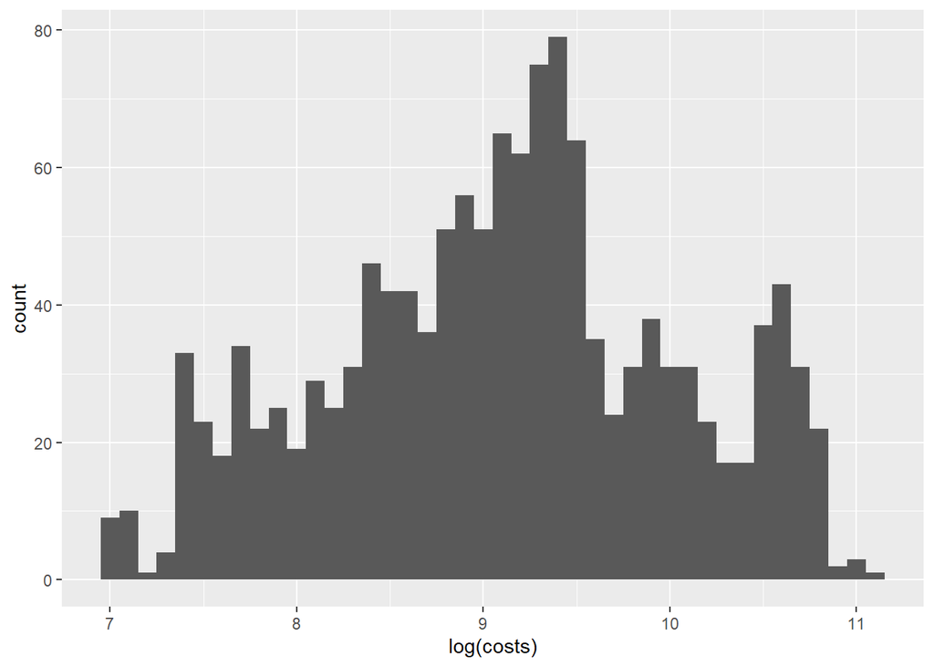

```r
#Attempt to normalize distribution of cost variable
ggplot(healthcare, aes(x = log(costs))) +
  geom_histogram(binwidth = .1)
```

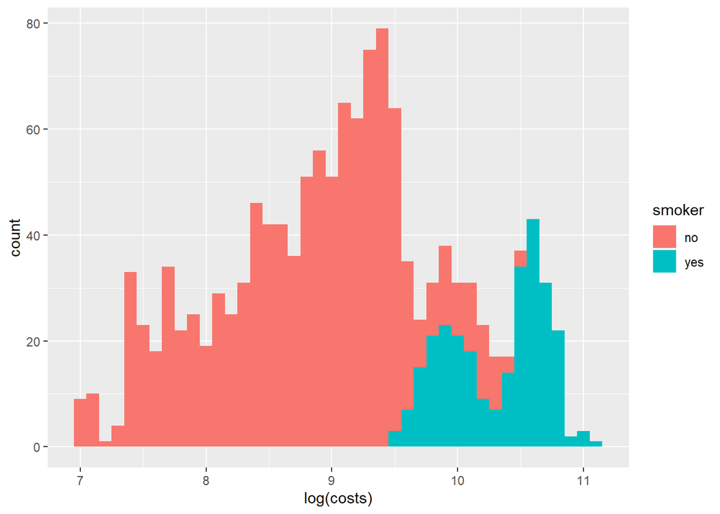

```r
#Smoker fill on cost histogram, shows smokers highly concentrated in higher levels of cost distribution
ggplot(healthcare, aes(x = log(costs), fill = smoker)) +
  geom_histogram(binwidth = .1)
```

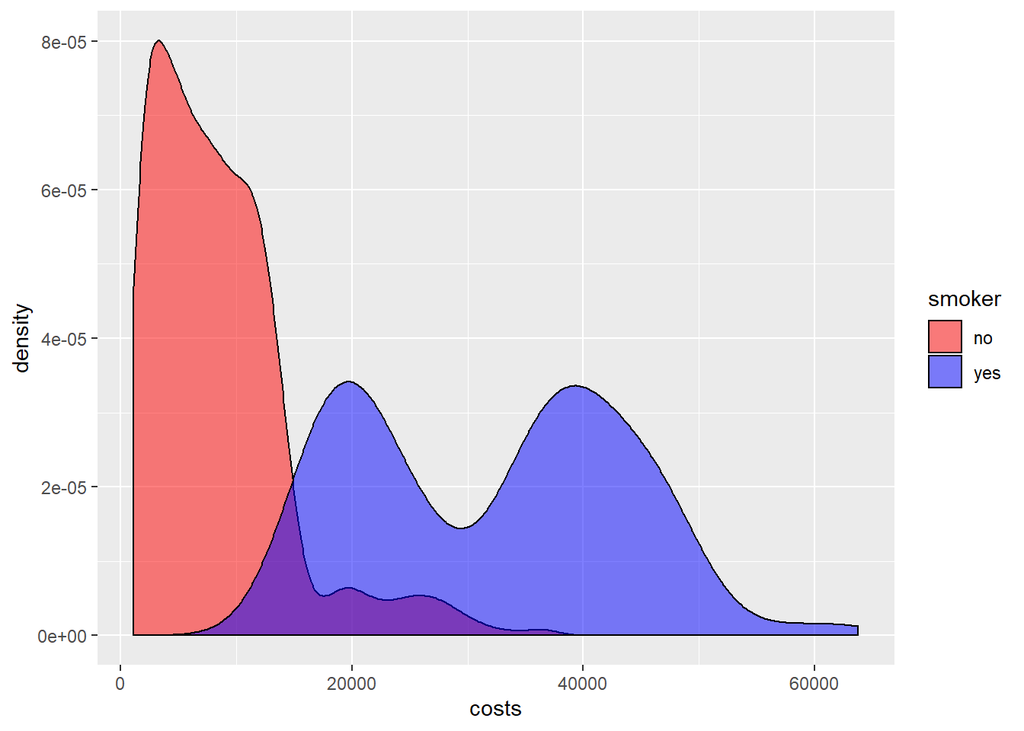

```r
#Density Plots
ggplot(healthcare, aes(x = costs, fill = smoker)) +
  geom_density(alpha = .5) +
  scale_fill_manual(values=c("red","blue"))
```

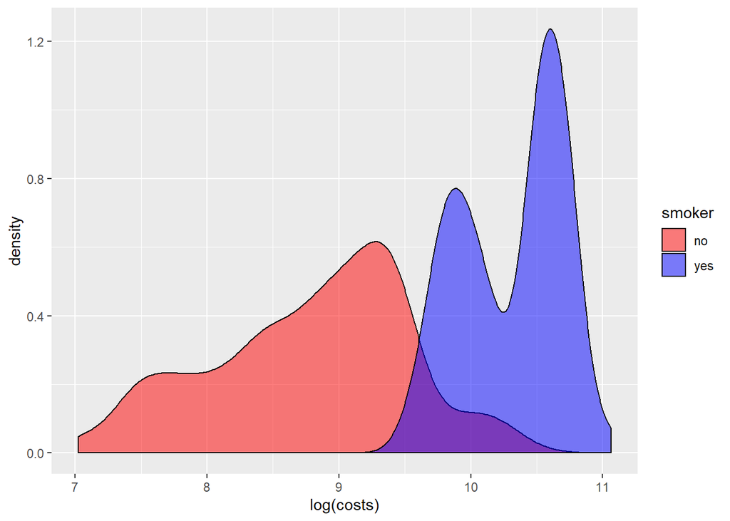

```r
ggplot(healthcare, aes(x = log(costs), fill = smoker)) +
  geom_density(alpha = .5) +
  scale_fill_manual(values=c("red","blue"))
```

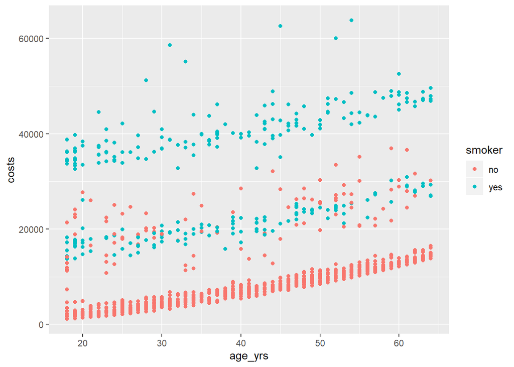

```r
#Plot of Age v. Costs showing distinct linear relationship (however there is jump in cost due to smoker = "Yes")
ggplot(healthcare, aes(x = age_yrs, y = costs, color = smoker)) +
  geom_point()
```

# 8 Mean model for evaluation.

Retrieve the average cost across all variables and retrieve RMSE to use as a base line for future model results.

```r
mean_model <- mean(healthcare$costs) - healthcare[["costs"]]
rmse_mean_model <- sqrt(mean(mean_model^2))
model_performance <- list()
model_performance[1] <- rmse_mean_model
names(model_performance) <- c("Mean Model")
model_performance
```

```
## $`Mean Model`
## [1] 12105.48
```

# 9 Train/Test set & model Formula.

Shuffle the data for prepartion of train/test sets, create train/test sets from shuffled data and create formula to be used for future models; from doing various analysis and checks on data, the variables and variable interactions in the code were selected.

```r
set.seed(42)
rows <- sample(nrow(healthcare))
healthcare <- healthcare[rows,]
assignment <- sample(1:3,
                     size = nrow(healthcare),
                     prob = c(.7, .15, .15),
                     replace = TRUE)
healthcare_train <- healthcare[assignment == 1,
                               -healthcare_factors]

healthcare_test <- healthcare[assignment == 2,
                              -healthcare_factors]

healthcare_valid <- healthcare[assignment == 3,
                               -healthcare_factors]
oslr_fm <- formula(costs ~
                     age_yrs +
                     body_mass +
                     no_children +
                     prev_balance +
                     smoker_num +
                     gender_num +
                     body_mass:smoker_num)
```

# 10 OSLR Model

Create OSLR model and check RMSE performance.

```r
oslr_model <- lm(formula = oslr_fm,
                 data = healthcare_train)
summary(oslr_model)
```

```
##
## Call:
## lm(formula = oslr_fm, data = healthcare_train)
##
## Residuals:
##      Min       1Q   Median       3Q      Max
## -11202.6  -2072.6  -1487.2   -674.6  24456.6
##
## Coefficients:
##                        Estimate Std. Error t value Pr(>|t|)
## (Intercept)          -2.151e+03  1.063e+03  -2.023  0.04337 *
## age_yrs               2.580e+02  1.223e+01  21.090  < 2e-16 ***
## body_mass             1.418e+01  3.138e+01   0.452  0.65137
## no_children           4.349e+02  1.360e+02   3.197  0.00144 **
## prev_balance         -4.686e-02  3.711e-02  -1.263  0.20707
## smoker_num           -2.252e+04  2.198e+03 -10.245  < 2e-16 ***
## gender_num           -6.492e+02  3.360e+02  -1.932  0.05367 .
## body_mass:smoker_num  1.506e+03  7.110e+01  21.176  < 2e-16 ***
## ---
## Signif. codes:  0 '***' 0.001 '**' 0.01 '*' 0.05 '.' 0.1 ' ' 1
##
## Residual standard error: 5067 on 912 degrees of freedom
## Multiple R-squared:  0.8154, Adjusted R-squared:  0.814
## F-statistic: 575.5 on 7 and 912 DF,  p-value: < 2.2e-16
```

```r
oslr_predict <- predict(oslr_model,
                        newdata = healthcare_test)
oslr_error <- oslr_predict - healthcare_test[["costs"]]
rmse_oslr_model <- sqrt(mean(oslr_error^2))
model_performance[2] <- rmse_oslr_model
names(model_performance) <- c("Mean Model",
                              "OSLR Model")
model_performance
```

```
## $`Mean Model`
## [1] 12105.48
##
## $`OSLR Model`
## [1] 4830.359
```

# 11 “RPart” model.

Prepare “Rpart” regression tree model and check RMSE performance.

```r
rpart_fm <- formula(costs ~
                      age_yrs +
                      body_mass +
                      no_children +
                      prev_balance +
                      smoker_num +
                      gender_num)

library(rpart)
library(rpart.plot)
rpart_model <- rpart(formula = rpart_fm,
                     data = healthcare_train,
                     method = "anova")
summary(rpart_model)
```

```
## Call:
## rpart(formula = rpart_fm, data = healthcare_train, method = "anova")
##   n= 920
##
##           CP nsplit rel error    xerror       xstd
## 1 0.59134727      0 1.0000000 1.0025261 0.06475266
## 2 0.14326606      1 0.4086527 0.4122696 0.02500495
## 3 0.06221475      2 0.2653867 0.2709036 0.01981592
## 4 0.01997344      3 0.2031719 0.2140310 0.01872174
## 5 0.01100712      4 0.1831985 0.1926375 0.01717773
## 6 0.01000000      5 0.1721914 0.1876509 0.01725569
##
## Variable importance
##   smoker_num prev_balance    body_mass      age_yrs   gender_num
##           57           19           14            7            1
##  no_children
##            1
##
## Node number 1: 920 observations,    complexity param=0.5913473
##   mean=13059.62, MSE=1.378784e+08
##   left son=2 (742 obs) right son=3 (178 obs)
##   Primary splits:
##       smoker_num   < 0.5       to the left,  improve=0.591347300, (0 missing)
##       prev_balance < 7368.672  to the left,  improve=0.215597700, (0 missing)
##       age_yrs      < 42.5      to the left,  improve=0.080511380, (0 missing)
##       body_mass    < 30.6375   to the left,  improve=0.033745420, (0 missing)
##       no_children  < 4.5       to the right, improve=0.002529006, (0 missing)
##   Surrogate splits:
##       prev_balance < -3525.396 to the right, agree=0.845, adj=0.197, (0 split)
##
## Node number 2: 742 observations,    complexity param=0.06221475
##   mean=8637.026, MSE=3.791798e+07
##   left son=4 (419 obs) right son=5 (323 obs)
##   Primary splits:
##       age_yrs      < 42.5      to the left,  improve=0.280497200, (0 missing)
##       prev_balance < -3018.681 to the right, improve=0.116100000, (0 missing)
##       body_mass    < 22.36     to the left,  improve=0.014036840, (0 missing)
##       no_children  < 0.5       to the left,  improve=0.012818190, (0 missing)
##       gender_num   < 0.5       to the right, improve=0.004514135, (0 missing)
##   Surrogate splits:
```

[output cut: 40 more lines]

```
##   Primary splits:
##       prev_balance < 3309.206  to the left,  improve=0.176434400, (0 missing)
##       no_children  < 0.5       to the left,  improve=0.114194800, (0 missing)
##       age_yrs      < 26.5      to the left,  improve=0.095455890, (0 missing)
##       body_mass    < 22.36     to the left,  improve=0.016455750, (0 missing)
##       gender_num   < 0.5       to the right, improve=0.003603712, (0 missing)
##
## Node number 9: 14 observations
##   mean=18999.53, MSE=3.010447e+07
##
## Node number 16: 396 observations
##   mean=5036.527, MSE=1.539356e+07
##
## Node number 17: 9 observations
##   mean=17632.67, MSE=4.683622e+07
```

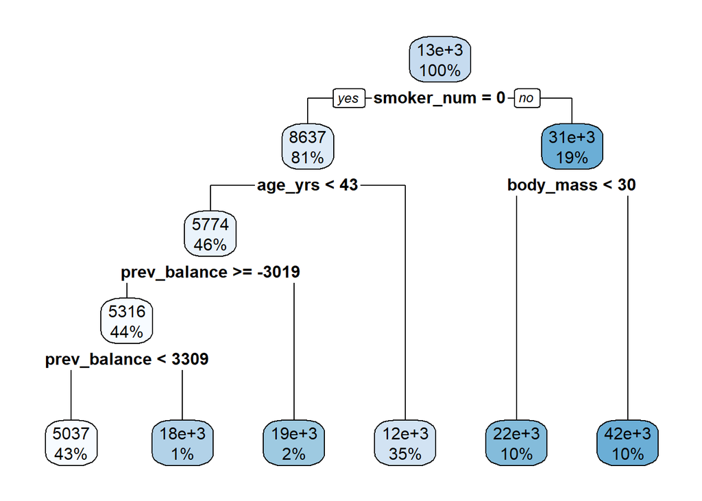

```r
rpart.plot(rpart_model)
```

```r
rpart_predict <- predict(rpart_model,
                         newdata = healthcare_test)
rpart_error <- rpart_predict - healthcare_test[["costs"]]
rmse_rpart_model <- sqrt(mean(rpart_error^2))
model_performance[3] <- rmse_rpart_model
names(model_performance) <- c("Mean Model",
                              "OSLR Model",
                              "RPart Model")
model_performance
```

```
## $`Mean Model`
## [1] 12105.48
##
## $`OSLR Model`
## [1] 4830.359
##
## $`RPart Model`
## [1] 4663.308
```

## 11.1 CP Tuning.

Perform CP tuning on “RPart” model to try and improve performance.

```r
print(rpart_model$cptable)
```

```
##           CP nsplit rel error    xerror       xstd
## 1 0.59134727      0 1.0000000 1.0025261 0.06475266
## 2 0.14326606      1 0.4086527 0.4122696 0.02500495
## 3 0.06221475      2 0.2653867 0.2709036 0.01981592
## 4 0.01997344      3 0.2031719 0.2140310 0.01872174
## 5 0.01100712      4 0.1831985 0.1926375 0.01717773
## 6 0.01000000      5 0.1721914 0.1876509 0.01725569
```

```r
opt_index <- which.min(rpart_model$cptable[, "xerror"])
cp_opt <- rpart_model$cptable[opt_index, "CP"]
rpart_model_cp <- prune(tree = rpart_model,
                        cp = cp_opt)
# rpart_model_cp
rpart_cp_predict <- predict(rpart_model_cp,
                            newdata = healthcare_test)
rpart_cp_error <- rpart_cp_predict - healthcare_test[["costs"]]
rmse_rpart_model_cp <- sqrt(mean(rpart_cp_error^2))
model_performance[4] <- rmse_rpart_model_cp
names(model_performance) <- c("Mean Model",
                              "OSLR Model",
                              "RPart Model",
                              "Rpart Model(CP)")
model_performance
```

```
## $`Mean Model`
## [1] 12105.48
##
## $`OSLR Model`
## [1] 4830.359
##
## $`RPart Model`
## [1] 4663.308
##
## $`Rpart Model(CP)`
## [1] 4663.308
```

## 11.2 Hyper Grid tuning.

Perform Hyper Grid tuning on “RPart” model to try and improve performance.

```r
library(Metrics)
minsplit <- seq(1, 8, 1)
maxdepth <- seq(1, 6, 1)
hyper_grid <- expand.grid(minsplit = minsplit,
                          maxdepth = maxdepth)
head(hyper_grid)
```

```
##   minsplit maxdepth
## 1        1        1
## 2        2        1
## 3        3        1
## 4        4        1
## 5        5        1
## 6        6        1
```

```r
nrow(hyper_grid)
```

```
## [1] 48
```

```r
num_rpart_models <- nrow(hyper_grid)
tune_rpart_models <- list()
for (i in 1:num_rpart_models) {
  minsplit <- hyper_grid$minsplit[i]
  maxdepth <- hyper_grid$maxdepth[i]

  tune_rpart_models[[i]] <- rpart(formula = rpart_fm,
                                  data = healthcare_train,
                                  method = "anova",
                                  minsplit = minsplit,
                                  maxdepth = maxdepth)
}
num_rpart_models <- length(tune_rpart_models)
rpart_rmse_values <- c()
for (i in 1:num_rpart_models) {
  model <- tune_rpart_models[[i]]

  pred <- predict(object = model,
                  newdata = healthcare_valid)

  rpart_rmse_values[i] <- rmse(actual = healthcare_valid$costs,
                               predicted = pred)
}
best_rpart_model <- tune_rpart_models[[which.min(rpart_rmse_values)]]
best_rpart_model$control
```

```
## $minsplit
## [1] 2
##
## $minbucket
## [1] 1
##
## $cp
## [1] 0.01
##
## $maxcompete
## [1] 4
##
## $maxsurrogate
## [1] 5
##
## $usesurrogate
## [1] 2
##
## $surrogatestyle
## [1] 0
##
## $maxdepth
## [1] 4
##
## $xval
## [1] 10
```

```r
pred <- predict(object = best_rpart_model,
                newdata = healthcare_test)
rmse_rpart_model_tune <- rmse(actual = healthcare_test$costs,
                              predicted = pred)
model_performance[5] <- rmse_rpart_model_tune
names(model_performance) <- c("Mean Model",
                              "OSLR Model",
                              "RPart Model",
                              "Rpart Model(CP)",
                              "Rpart Model(Tune)")
model_performance
```

```
## $`Mean Model`
## [1] 12105.48
##
## $`OSLR Model`
## [1] 4830.359
##
## $`RPart Model`
## [1] 4663.308
##
## $`Rpart Model(CP)`
## [1] 4663.308
##
## $`Rpart Model(Tune)`
## [1] 4655.995
```

# 12 Bootstrap model.

Perform Bootstrap model on dataset to try and improve model performance.

```r
library(ipred)
set.seed(42)
rpart_bag_model <- bagging(formula = rpart_fm,
                           data = healthcare_train,
                           coob = TRUE)
rpart_bag_model
```

```
##
## Bagging regression trees with 25 bootstrap replications
##
## Call: bagging.data.frame(formula = rpart_fm, data = healthcare_train,
##     coob = TRUE)
##
## Out-of-bag estimate of root mean squared error:  4659.313
```

```r
rpart_bag_prediction <- predict(rpart_bag_model,
                                newdata = healthcare_test)
rmse_rpart_bootstrap <- rmse(actual = healthcare_test$costs,
                             predicted = rpart_bag_prediction)
model_performance[6] <- rmse_rpart_bootstrap
names(model_performance) <- c("Mean Model",
                              "OSLR Model",
                              "RPart Model",
                              "Rpart Model(CP)",
                              "Rpart Model(Tune)",
                              "Rpart Model(Bootstrap)")
model_performance
```

```
## $`Mean Model`
## [1] 12105.48
##
## $`OSLR Model`
## [1] 4830.359
##
## $`RPart Model`
## [1] 4663.308
##
## $`Rpart Model(CP)`
## [1] 4663.308
##
## $`Rpart Model(Tune)`
## [1] 4655.995
##
## $`Rpart Model(Bootstrap)`
## [1] 4042.309
```

# 13 GBM model.

Perform Gradient Boosting on dataset to try and improve model performan.

```r
library(gbm)
set.seed(42)
rpart_boost_model <- gbm(formula = rpart_fm,
                         distribution = "gaussian",
                         data = healthcare_train,
                         n.trees = 50000,
                         cv = 10)
gbm_opt <- gbm.perf(rpart_boost_model)
```

[figure not shown]

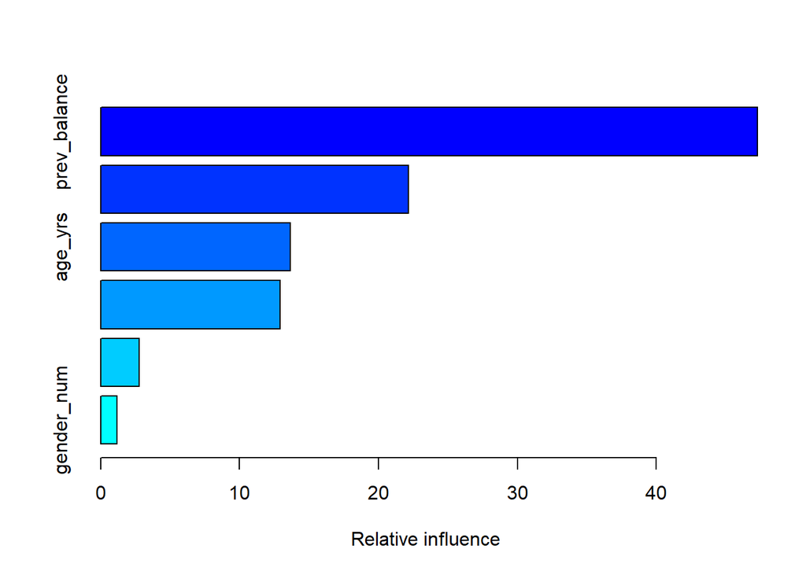

```
##                       var   rel.inf
## prev_balance prev_balance 47.289166
## body_mass       body_mass 22.147405
## age_yrs           age_yrs 13.656788
## smoker_num     smoker_num 12.937827
## no_children   no_children  2.786654
## gender_num     gender_num  1.182161
```

```r
summary(rpart_boost_model)
```

```r
rpart_boost_prediction <- predict(rpart_boost_model,
                                  newdata = healthcare_test,
                                  n.trees = gbm_opt)
rmse_rpart_boost_model <- rmse(actual = healthcare_test$costs,
                               predicted = rpart_boost_prediction)
model_performance[7] <- rmse_rpart_boost_model
names(model_performance) <- c("Mean Model",
                              "OSLR Model",
                              "RPart Model",
                              "Rpart Model(CP)",
                              "Rpart Model(Tune)",
                              "Rpart Model(Bootstrap)",
                              "Rpart Model(Boost)")
model_performance
```

```
## $`Mean Model`
## [1] 12105.48
##
## $`OSLR Model`
## [1] 4830.359
##
## $`RPart Model`
## [1] 4663.308
##
## $`Rpart Model(CP)`
## [1] 4663.308
##
## $`Rpart Model(Tune)`
## [1] 4655.995
##
## $`Rpart Model(Bootstrap)`
## [1] 4042.309
##
## $`Rpart Model(Boost)`
## [1] 6098.14
```

# 14 Conclusion.

Based on the RMSE the ideal model that was created is the Bootstrapped model, however,considering the RMSE, the initial OSLR model shows a significant RMSE when considering time and complexity of models. With ime constraint and conveying analysis to Business Decision Makers, the OSLR model could be ideal. Comments: Somewhat unknown as why tuning parameters did not improve “RPart” model and would like feedback on this.